# BestCarsInc

## Individual Project Vehicles

[figure not shown]

by [Oksana Palej](https://www.linkedin.com/in/oksana-palej-/)

Vehicles and its Data Introduction First of all we are going to do an analysis of a database on the whole vehicles. We will use some of the most important attributes in Python such as Pandas, Matloplib, Seaborn, etc. to show plots of multiple aspects of different events with the goal of displaying an unreadable database and turning it into something much friendlier.

# Content of this Notebook

1. **Introduction**

In this notebook, we will analyze vehicle data from the provided CSV file located at [Kaggle](https://www.kaggle.com/). We'll perform data cleaning, exploration, and draw insights from the dataset.

1. **First Look**
   - Loading the dataset.
   - Displaying the first ten rows.
   - Inferring feature meanings.
   - Counting unique feature values.
   - Providing a statistical summary.
   - Identifying issues and anomalies.
1. **Data Cleaning**

   3.1. Remove redundant and sparse features
   - Eliminating 'URL,' 'image_url,' and 'city_url' features.
   - Removing features with over 40% missing values.

   3.2. Outlier Handling
   - Addressing outliers in 'price,' 'year,' and 'odometer.'
   - Setting reasonable value ranges.
   - Removing data points outside defined ranges.
   - Eliminating rows with null values.
1. **Feature Relations**

   4.1. Correlation Analysis
   - Visualizing the correlation matrix.
   - Explaining the positive correlation between price and year.
   - Providing a scatter plot for the correlation.
   - Explaining the negative correlation between price and odometer.
   - Including a scatter plot.

   4.2. Seaborn Analysis
   - Using Seaborn's pairplot() for comprehensive scatterplot analysis.
1. **Feature Analysis**

   5.1. Value Distribution
   - Exploring feature value distributions.

   5.2. Odometer Histogram
   - Plotting a histogram of 'odometer' with 50 bins.
   - Explaining patterns observed.

   5.3. Year Histogram
   - Plotting a histogram of 'year' with 20 bins.
   - Interpreting findings.
1. **Conclusion**
   - Summarizing key points.
   - Organizing information coherently.
   - Providing recommendations or insights.

```python
# importing python libraries
import numpy as np
import pandas as pd
import seaborn as sns
import matplotlib.pyplot as plt
```

## First Look

### 1. Loading of dataset

```python
vehicles = "vehicles.csv"
```

```python
df = pd.read_csv(vehicles)
```

### 2. Show the first ten rows.

```python
df.head(10)
```

|  | id | url | region | region_url | price | year | manufacturer | model | condition | cylinders | ... | size | type | paint_color | image_url | description | county | state | lat | long | posting_date |
| --- | --- | --- | --- | --- | --- | --- | --- | --- | --- | --- | --- | --- | --- | --- | --- | --- | --- | --- | --- | --- | --- |
| 0 | 7222695916 | https://prescott.craigslist.org/cto/d/prescott... | prescott | https://prescott.craigslist.org | 6000 | NaN | NaN | NaN | NaN | NaN | ... | NaN | NaN | NaN | NaN | NaN | NaN | az | NaN | NaN | NaN |
| 1 | 7218891961 | https://fayar.craigslist.org/ctd/d/bentonville... | fayetteville | https://fayar.craigslist.org | 11900 | NaN | NaN | NaN | NaN | NaN | ... | NaN | NaN | NaN | NaN | NaN | NaN | ar | NaN | NaN | NaN |
| 2 | 7221797935 | https://keys.craigslist.org/cto/d/summerland-k... | florida keys | https://keys.craigslist.org | 21000 | NaN | NaN | NaN | NaN | NaN | ... | NaN | NaN | NaN | NaN | NaN | NaN | fl | NaN | NaN | NaN |
| 3 | 7222270760 | https://worcester.craigslist.org/cto/d/west-br... | worcester / central MA | https://worcester.craigslist.org | 1500 | NaN | NaN | NaN | NaN | NaN | ... | NaN | NaN | NaN | NaN | NaN | NaN | ma | NaN | NaN | NaN |
| 4 | 7210384030 | https://greensboro.craigslist.org/cto/d/trinit... | greensboro | https://greensboro.craigslist.org | 4900 | NaN | NaN | NaN | NaN | NaN | ... | NaN | NaN | NaN | NaN | NaN | NaN | nc | NaN | NaN | NaN |
| 5 | 7222379453 | https://hudsonvalley.craigslist.org/cto/d/west... | hudson valley | https://hudsonvalley.craigslist.org | 1600 | NaN | NaN | NaN | NaN | NaN | ... | NaN | NaN | NaN | NaN | NaN | NaN | ny | NaN | NaN | NaN |
| 6 | 7221952215 | https://hudsonvalley.craigslist.org/cto/d/west... | hudson valley | https://hudsonvalley.craigslist.org | 1000 | NaN | NaN | NaN | NaN | NaN | ... | NaN | NaN | NaN | NaN | NaN | NaN | ny | NaN | NaN | NaN |
| 7 | 7220195662 | https://hudsonvalley.craigslist.org/cto/d/poug... | hudson valley | https://hudsonvalley.craigslist.org | 15995 | NaN | NaN | NaN | NaN | NaN | ... | NaN | NaN | NaN | NaN | NaN | NaN | ny | NaN | NaN | NaN |
| 8 | 7209064557 | https://medford.craigslist.org/cto/d/grants-pa... | medford-ashland | https://medford.craigslist.org | 5000 | NaN | NaN | NaN | NaN | NaN | ... | NaN | NaN | NaN | NaN | NaN | NaN | or | NaN | NaN | NaN |
| 9 | 7219485069 | https://erie.craigslist.org/cto/d/erie-2012-su... | erie | https://erie.craigslist.org | 3000 | NaN | NaN | NaN | NaN | NaN | ... | NaN | NaN | NaN | NaN | NaN | NaN | pa | NaN | NaN | NaN |

10 rows × 26 columns

### 4. Count the unique values of each feature.

```python
# Calculate the number of unique values for each column
unique_counts = df.nunique()

# Print the unique counts for each column
print(unique_counts)
```

```
id              426880
url             426880
region             404
region_url         413
price            15655
year               114
manufacturer        42
model            29667
condition            6
cylinders            8
fuel                 5
odometer        104870
title_status         6
transmission         3
VIN             118264
drive                3
size                 4
type                13
paint_color         12
image_url       241899
description     360911
county               0
state               51
lat              53181
long             53772
posting_date    381536
dtype: int64
```

### 5. Providing a statistical summary.

```python
# Get a statistical summary of the DataFrame
summary = df.describe()

# Print the summary
print(summary)
```

```
                 id         price           year      odometer  county  \
count  4.268800e+05  4.268800e+05  425675.000000  4.224800e+05     0.0
mean   7.311487e+09  7.519903e+04    2011.235191  9.804333e+04     NaN
std    4.473170e+06  1.218228e+07       9.452120  2.138815e+05     NaN
min    7.207408e+09  0.000000e+00    1900.000000  0.000000e+00     NaN
25%    7.308143e+09  5.900000e+03    2008.000000  3.770400e+04     NaN
50%    7.312621e+09  1.395000e+04    2013.000000  8.554800e+04     NaN
75%    7.315254e+09  2.648575e+04    2017.000000  1.335425e+05     NaN
max    7.317101e+09  3.736929e+09    2022.000000  1.000000e+07     NaN

                 lat           long
count  420331.000000  420331.000000
mean       38.493940     -94.748599
std         5.841533      18.365462
min       -84.122245    -159.827728
25%        34.601900    -111.939847
50%        39.150100     -88.432600
75%        42.398900     -80.832039
max        82.390818     173.885502
```

```python
# Get a statistical summary of the entire DataFrame (including non-numeric columns)
summary = df.describe(include='all')

# Print the summary
print(summary)
```

```
                  id                                                url  \
count   4.268800e+05                                             426880
unique           NaN                                             426880
top              NaN  https://prescott.craigslist.org/cto/d/prescott...
freq             NaN                                                  1
mean    7.311487e+09                                                NaN
std     4.473170e+06                                                NaN
min     7.207408e+09                                                NaN
25%     7.308143e+09                                                NaN
50%     7.312621e+09                                                NaN
75%     7.315254e+09                                                NaN
max     7.317101e+09                                                NaN

          region                      region_url         price           year  \
count     426880                          426880  4.268800e+05  425675.000000
unique       404                             413           NaN            NaN
top     columbus  https://spokane.craigslist.org           NaN            NaN
freq        3608                            2988           NaN            NaN
mean         NaN                             NaN  7.519903e+04    2011.235191
std          NaN                             NaN  1.218228e+07       9.452120
min          NaN                             NaN  0.000000e+00    1900.000000
25%          NaN                             NaN  5.900000e+03    2008.000000
50%          NaN                             NaN  1.395000e+04    2013.000000
75%          NaN                             NaN  2.648575e+04    2017.000000
max          NaN                             NaN  3.736929e+09    2022.000000

       manufacturer   model condition    cylinders  ...       size    type  \
count        409234  421603    252776       249202  ...     120519  334022
unique           42   29667         6            8  ...          4      13
top            ford   f-150      good  6 cylinders  ...  full-size   sedan
freq          70985    8009    121456        94169  ...      63465   87056
mean            NaN     NaN       NaN          NaN  ...        NaN     NaN
std             NaN     NaN       NaN          NaN  ...        NaN     NaN
min             NaN     NaN       NaN          NaN  ...        NaN     NaN
25%             NaN     NaN       NaN          NaN  ...        NaN     NaN
50%             NaN     NaN       NaN          NaN  ...        NaN     NaN
75%             NaN     NaN       NaN          NaN  ...        NaN     NaN
max             NaN     NaN       NaN          NaN  ...        NaN     NaN

       paint_color                                          image_url  \
```

[output cut: 24 more lines]

```

                  lat           long              posting_date
count   420331.000000  420331.000000                    426812
unique            NaN            NaN                    381536
top               NaN            NaN  2021-04-23T22:13:05-0400
freq              NaN            NaN                        12
mean        38.493940     -94.748599                       NaN
std          5.841533      18.365462                       NaN
min        -84.122245    -159.827728                       NaN
25%         34.601900    -111.939847                       NaN
50%         39.150100     -88.432600                       NaN
75%         42.398900     -80.832039                       NaN
max         82.390818     173.885502                       NaN

[11 rows x 26 columns]
```

In the statistical summary there are a few points to note:

In summary, the 'county' feature appears to be empty, and there may be outliers in the 'price' and 'odometer' features. We should carefully examine and clean our data to handle missing values and outliers appropriately before performing further analysis or modeling. Additionally, the 'year' feature may require validation to ensure the accuracy of the data.

### 6. Identifying issues and anomalies.

#### 6.1. We have a categorical feature: ‘condition.’ What are its values? Is everything ok with it? Why?

```
[nan 'good' 'excellent' 'fair' 'like new' 'new' 'salvage']
good         121456
excellent    101467
like new      21178
fair           6769
new            1305
salvage         601
Name: condition, dtype: int64
good         48.048865
excellent    40.141074
like new      8.378169
fair          2.677865
new           0.516267
salvage       0.237760
Name: condition, dtype: float64
```

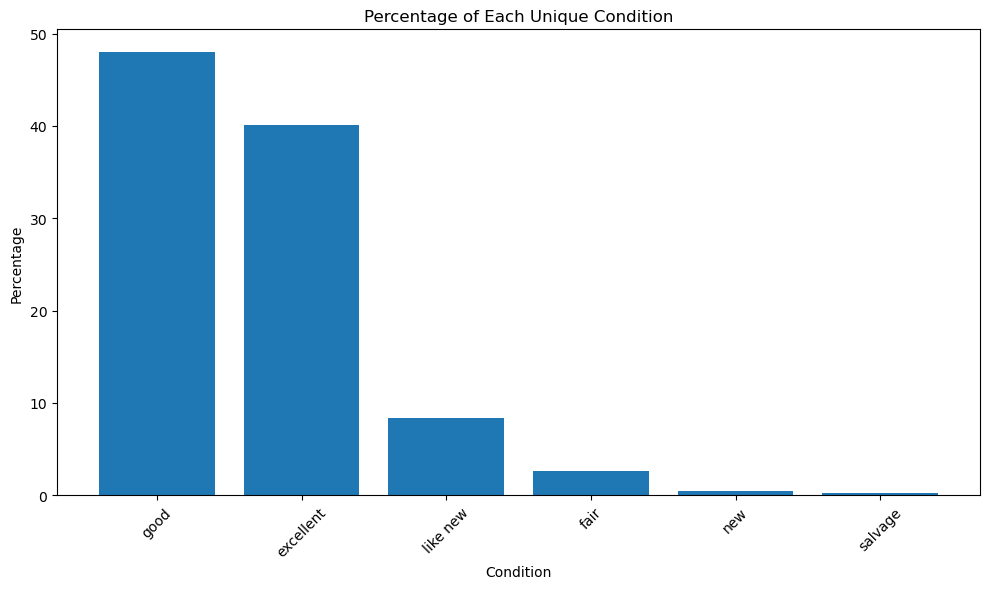

```python
# y quieres contar la frecuencia de cada condición única
unique_conditions = df['condition'].unique()
print(unique_conditions)

# Calcula la frecuencia de cada condición única
counts = df['condition'].value_counts()
print(counts)

# Calcula los porcentajes
percentages = (counts / counts.sum()) * 100
print(percentages)

# Crea un DataFrame con las condiciones únicas y sus porcentajes
data = pd.DataFrame({'Condition': counts.index, 'Percentage': percentages})

# Ordena el DataFrame por porcentaje (opcional)
data = data.sort_values(by='Percentage', ascending=False)

# Crea el gráfico de barras apiladas verticalmente en porcentaje
plt.figure(figsize=(10, 6))
plt.bar(data['Condition'], data['Percentage'])
plt.xlabel('Condition')
plt.ylabel('Percentage')
plt.title('Percentage of Each Unique Condition')
plt.xticks(rotation=45)  # Rotar etiquetas del eje x para mejorar la legibilidad
plt.tight_layout()
plt.show()
```

```python
# Calculate the number of NaN values in the 'condition' column
nan_count = df['condition'].isna().sum()

# Calculate the percentage of NaN values in the 'condition' column
total_count = len(df['condition'])
percentage_nan = (nan_count / total_count) * 100

# Print the percentage of NaN values
print(f'The percentage of NaN values in the "condition" column is: {percentage_nan:.2f}%')
```

```
The percentage of NaN values in the "condition" column is: 40.79%
```

Since the data represents customer evaluation in terms of car ratings, it appears that this data is categorical rather than numerical. In this case, the values "good," "excellent," "like new," "fair," "new," and "salvage" are the possible categories for the "condition" column. After obtaining such a high percentage of NaN values, it is possible that they are incorrectly encoded or that there are no actual missing values in this column.

Given that the values in the "condition" column are categorical and not numerical, it does not make sense to have NaN values in this column unless it is an error in data collection or processing.

After conducting a thorough review, you find that the NaN values in the "condition" column are legitimate and correspond to cases where a condition evaluation was not provided, so we will consider imputing a representative value ("Unknown").

```python
df['condition'].fillna('Unknown', inplace=True)
```

```python
unique_conditions = df["condition"].unique()
print (unique_conditions)
```

```
['Unknown' 'good' 'excellent' 'fair' 'like new' 'new' 'salvage']
```

```python
# Calculate the number of observations for each unique condition
unique_conditions = df['condition'].value_counts()
print(unique_conditions)
```

```
Unknown      174104
good         121456
excellent    101467
like new      21178
fair           6769
new            1305
salvage         601
Name: condition, dtype: int64
```

Maintaining null values (NaN) in the "condition" column instead of removing them can have some potential implications for further study:

1. **Introduction of noise in the analysis:** By replacing null values with 'Unknown,' you are introducing an additional category that was not present in the original data. This can affect the interpretation of results and the analysis of vehicle conditions, as 'Unknown' is now considered a valid category.
2. **Impact on descriptive statistics:** The inclusion of 'Unknown' can influence descriptive statistics such as mean, median, and standard deviation, potentially leading to a biased representation of the distribution of vehicle conditions.
3. **Potential impact on machine learning models:** If you plan to use this data in machine learning models, the presence of the 'Unknown' category can affect model performance. Models may treat 'Unknown' as a legitimate category and learn relationships based on this information.
4. **Difficulty in interpretation:** In subsequent analyses, it may be more challenging to interpret vehicle conditions when the 'Unknown' category is included. The lack of information about the actual condition of these vehicles can be a hurdle in understanding real patterns and trends.

Overall, the decision to replace null values with 'Unknown' was made to preserve data integrity and avoid data loss. However, it is essential to be aware of the potential implications for further analysis and consider them when conducting any future studies or analyses.

#### 6.2. Working with the **‘condition’** feature, it has syntactic problems, i.e., nan values, but also semantic problems: the ‘like new’ value has the same meaning as ‘excellent.’?

In this case, "like new" and "excellent": "Like new" typically implies a nearly new or excellent condition. Therefore, we decided to merge these two categories into "excellent" to simplify the representation.

```python
# Reassign 'like new' to 'excellent'
df['condition'].replace('like new', 'excellent', inplace=True)

# Reassign 'good' and 'fair' to 'good'
df['condition'].replace(['good', 'fair'], 'good', inplace=True)

# Reassign 'excellent' and 'like new' to 'excellent'
df['condition'].replace(['excellent', 'like new'], 'excellent', inplace=True)
```

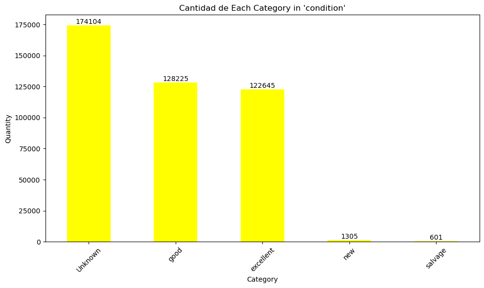

```python
# Calcular la cantidad de cada categoría
category_counts = df["condition"].value_counts()

# Crear el gráfico de barras
plt.figure(figsize=(10, 6))  # Ajusta el tamaño del gráfico si es necesario
category_counts.plot(kind="bar", color="yellow")
plt.title("Cantidad de Each Category in 'condition'")
plt.xlabel("Category")
plt.ylabel("Quantity")
plt.xticks(rotation=45)  # Rota las etiquetas del eje x para una mejor visualización

# Agregar etiquetas de texto encima de cada barra
for index, value in enumerate(category_counts):
    plt.text(index, value, str(value), ha='center', va='bottom', fontsize=10)

# Mostrar el gráfico
plt.tight_layout()
plt.show()
```

Here we can observe a bar chart that displays the quantity of each category in the **"condition"** column.

A brief description of each category:

1. **Unknown**: This category is used when there is no information or knowledge about the condition of the object in question.
2. **Good**: It represents that the object is in generally acceptable and functional condition. It may have some normal signs of wear but is in good overall condition.
3. **Excellent**: Indicates that the object is in exceptionally good condition. It may appear almost new and is in a superior state in terms of appearance and performance.
4. **New**: This category is reserved for objects that are brand new and have not been previously used.
5. **Salvage**: It is used for objects that have suffered significant damage and are considered total losses. "Salvage" objects typically require extensive repairs to be usable again.

# 3. Cleaning data

[figure not shown]

## 3.1. Remove redundant and sparse features

```
  - Eliminating 'URL', 'image_url,' and 'city_url' features.
  - Removing features with over 40% missing values.
```

1. **Remove redundant and sparse features.**
2. **Remove redundant or unusable data: drop the *'URL,' 'image_url,'* and *'city_url'* features.**
3. **Remove any feature that has more than 40% of null values.**
4. **What are the remaining features?**

```python
df.columns
```

```
Index(['id', 'url', 'region', 'region_url', 'price', 'year', 'manufacturer',
       'model', 'condition', 'cylinders', 'fuel', 'odometer', 'title_status',
       'transmission', 'VIN', 'drive', 'size', 'type', 'paint_color',
       'image_url', 'description', 'county', 'state', 'lat', 'long',
       'posting_date'],
      dtype='object')
```

```python
# Para ver los valores únicos de 'title_status':

unique_title_status = df['title_status'].unique()

# Imprime los valores únicos
print(unique_title_status)
```

```
[nan 'clean' 'rebuilt' 'lien' 'salvage' 'missing' 'parts only']
```

```python
nan_percentage_title_status = (df['title_status'].isna().sum() / len(df)) * 100

# Imprime el porcentaje total de NaN en 'title_status'
print(f"Porcentaje total de NaN en 'title_status': {nan_percentage_title_status:.2f}%")
```

```
Porcentaje total de NaN en 'title_status': 1.93%
```

```python
nan_percentage_title_status = (df['title_status'].isna().sum() / len(df)) * 100

# Imprime el porcentaje total de NaN en 'title_status'
print(f"Porcentaje total de NaN en 'title_status': {nan_percentage_title_status:.2f}%")
```

```
Porcentaje total de NaN en 'title_status': 1.93%
```

**After conducting a visual analysis of the DataFrame, I have decided to remove the following columns:**

- **'id':** If it serves only as a unique identifier without additional information, it may be considered *irrelevant* for the analysis.
- **'url' and 'region_url':** These columns may be *irrelevant* if there are no plans to utilize specific URL or region information in the analysis.
- **'county':** This column lacks any meaningful information and will be removed.
- **'image_url' and 'description':** Since this analysis does not involve image processing or descriptive text, these columns may be considered *irrelevant*.
- **'VIN':** The Vehicle Identification Number (*VIN*) is crucial for legal and verification purposes but may not be essential for specific analyses unless investigating issues related to vehicle authenticity.

```python
# List of columns to remove
columns_to_remove = ['id', 'url', 'region_url', 'county', 'image_url', 'VIN']

# Create a new DataFrame without the specified columns
clean_df = df.drop(columns=columns_to_remove)
```

```python
clean_df.shape
```

```
(426880, 20)
```

1. **Remove any feature that has more than 40% of null values.**

```python
# Calculate the total NaN in each column
nan_count = clean_df.isna().sum()

# Calculate the percentage of NaN in each column and round to 2 decimals
nan_percentage = (nan_count / len(clean_df)) * 100
nan_percentage = nan_percentage.round(2)  # Round to 2 decimals

# Combine the results into a new DataFrame
nan_summary = pd.DataFrame({'Column Name': nan_count.index, 'Total NaN': nan_count.values, 'Percentage NaN': nan_percentage.values})

# Sort the DataFrame by 'Percentage NaN' in descending order
nan_summary = nan_summary.sort_values(by='Percentage NaN', ascending=False)

# Display the summary
print(nan_summary)
```

```
     Column Name  Total NaN  Percentage NaN
12          size     306361           71.77
6      cylinders     177678           41.62
11         drive     130567           30.59
14   paint_color     130203           30.50
13          type      92858           21.75
3   manufacturer      17646            4.13
9   title_status       8242            1.93
18          long       6549            1.53
17           lat       6549            1.53
4          model       5277            1.24
8       odometer       4400            1.03
7           fuel       3013            0.71
10  transmission       2556            0.60
2           year       1205            0.28
15   description         70            0.02
19  posting_date         68            0.02
16         state          0            0.00
1          price          0            0.00
5      condition          0            0.00
0         region          0            0.00
```

*As we can see I have made the decision to remove the 'cylinder' column* because it has **more than 40%** of missing values. Although it is important in this case, it does not provide essential information. This action will simplify our data and prevent the missing values from negatively impacting our analysis. In the event that it proves crucial, we could consider gathering additional data from a reliable source to enhance the integrity of our dataset.

1. **What are the remaining features?**

```python
# Calculate the percentage of null values in each column
null_percentage = (clean_df.isnull().sum() / len(clean_df)) * 100

# Define a threshold (40% in this case)
threshold = 40

# Identify columns with null values exceeding the threshold
columns_to_drop = null_percentage[null_percentage > threshold].index

# Remove the identified columns from the DataFrame
df_cleaned = clean_df.drop(columns=columns_to_drop)

# df_cleaned now contains the DataFrame with columns having less than 40% of null values.
```

```python
# Calculate the percentage of NaN in each column of the cleaned DataFrame and round to 2 decimal places
nan_percentage = (df_cleaned.isnull().sum() / len(df_cleaned) * 100).round(2)

# Print the NaN percentage for each column
print("Percentage of NaN in each column of the cleaned DataFrame:")
print(nan_percentage)
```

```
Percentage of NaN in each column of the cleaned DataFrame:
region           0.00
price            0.00
year             0.28
manufacturer     4.13
model            1.24
condition        0.00
fuel             0.71
odometer         1.03
title_status     1.93
transmission     0.60
drive           30.59
type            21.75
paint_color     30.50
description      0.02
state            0.00
lat              1.53
long             1.53
posting_date     0.02
dtype: float64
```

## 3.2 Remove Outliers

```
  - Addressing outliers in 'price,' 'year,' and 'odometer.'
  - Setting reasonable value ranges.
  - Removing data points outside defined ranges.
  - Eliminating rows with null values.
```

Outlier values are **values outside reasonable boundaries**. For example, if you manage an industrial oven with a working range between **1500ºC and 2100ºC**, a reading of **6000ºC is an outlier** (*At 6000ºC, the oven would have already exploded*). Another example: You are a banker and suddenly see a drop in the price of Apple stock of **63%**. Is it an outlier? Why?

We detected an outlier problem with **‘price,’ ‘year,’ and ‘odometer.’**

- **Set a reasonable range** for the three features. Explain your decision.
- **Remove the data point (rows)** that doesn’t comply with your defined ranges.
- **Remove any data point with null values.**

What’s the resulting number of rows? What percentage of rows did we remove due to the cleaning and removing of outliers? Is the dataset still usable? Why?

```python
# Calculate the minimum and maximum price
min_price = df_cleaned['price'].min()
max_price = df_cleaned['price'].max()

# Display the price range
print("Minimum price:", min_price)
print("Maximum price:", max_price)

# Calculate the minimum and maximum year
min_year = df_cleaned['year'].min()
max_year = df_cleaned['year'].max()

# Display the year range
print("Minimum year:", min_year)
print("Maximum year:", max_year)

# Calculate the minimum and maximum odometer reading
min_odometer = df_cleaned['odometer'].min()
max_odometer = df_cleaned['odometer'].max()

# Display the odometer reading range
print("Minimum odometer reading:", min_odometer)
print("Maximum odometer reading:", max_odometer)
```

```
Minimum price: 0
Maximum price: 3736928711
Minimum year: 1900.0
Maximum year: 2022.0
Minimum odometer reading: 0.0
Maximum odometer reading: 10000000.0
```

### Data Analysis Results and Conclusions

- **Minimum price:** 0
  - This indicates that the minimum price in the dataset is $0, which is unusual for a car price. It could be an indication of missing or incorrect data.
- **Maximum price:** 3,736,928,711
  - The maximum price is extremely high, far beyond typical car prices. Such an outlier value could be due to data entry errors or inaccuracies in the dataset.
- **Minimum year:** 1900.0
  - The minimum year is 1900, which is unusual for cars. It's possible that this value represents very old or antique vehicles.
- **Maximum year:** 2022.0
  - The maximum year is 2022, which is expected as it represents the current year. Newer cars in the dataset are from this year.
- **Minimum odometer reading:** 0.0
  - The minimum odometer reading is 0, which is unusual because a car should have a non-zero mileage reading from the moment it is used.
- **Maximum odometer reading:** 10,000,000.0
  - The maximum odometer reading is quite high and might represent a vehicle with very high mileage. However, it's important to ensure the accuracy of such values.

**Conclusions:**

1. The dataset contains some anomalies and outliers in the 'price' and 'odometer' columns, which may require further investigation and cleaning.
2. The 'price' column has both very low (0) and extremely high values, which could be due to data entry errors or inconsistencies.
3. The 'year' column spans from 1900 to 2022, which includes a wide range of vehicle model years, including some potentially very old or antique cars.
4. The 'odometer' column also has outliers, with a maximum reading of 10,000,000 miles, which might represent vehicles with exceptionally high mileage.
5. It's essential to review and clean these outlier values to ensure the dataset's accuracy and usefulness for analysis.

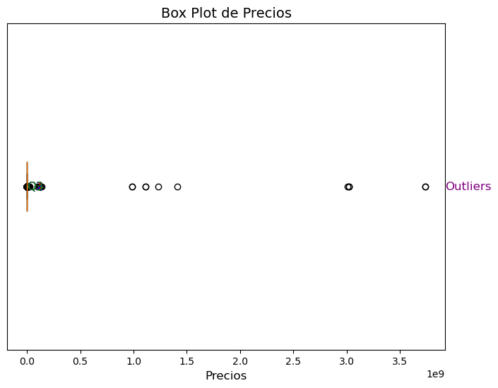

```python
# Crear el box plot y agregar etiquetas a los cuartiles
plt.figure(figsize=(8, 6))  # Ajusta el tamaño de la figura
plt.boxplot(df['price'], vert=False)  # Crea un box plot horizontal

# Calcula los cuartiles
q1 = df_cleaned['price'].quantile(0.25)
q2 = df_cleaned['price'].quantile(0.5)
q3 = df_cleaned['price'].quantile(0.75)

# Etiquetas para los cuartiles
plt.text(q1, 1, 'Q1', verticalalignment='center', fontsize=12, color='red')
plt.text(q2, 1, 'Q2', verticalalignment='center', fontsize=12, color='blue')
plt.text(q3, 1, 'Q3', verticalalignment='center', fontsize=12, color='green')

# Etiquetas para los valores atípicos
plt.text(plt.xlim()[1], 1, 'Outliers', verticalalignment='center', fontsize=12, color='purple')

plt.xlabel('Precios', fontsize=12)
plt.title('Box Plot de Precios', fontsize=14)
plt.yticks([])  # Elimina las etiquetas del eje y

plt.show()
```

```python
# Calcular los cuartiles
q1 = df_cleaned['price'].quantile(0.25)
q3 = df_cleaned['price'].quantile(0.75)

# Calcular el rango intercuartil (IQR)
iqr = q3 - q1

# Definir los umbrales para valores atípicos
umbral_inferior = q1 - 1.5 * iqr
umbral_superior = q3 + 1.5 * iqr

# Filtrar las filas que no son valores atípicos
df_sin_outliers = df_cleaned[(df_cleaned['price'] >= umbral_inferior) & (df_cleaned['price'] <= umbral_superior)]

# Ahora 'df_sin_outliers' contiene el DataFrame original con los dos últimos outliers eliminados.
```

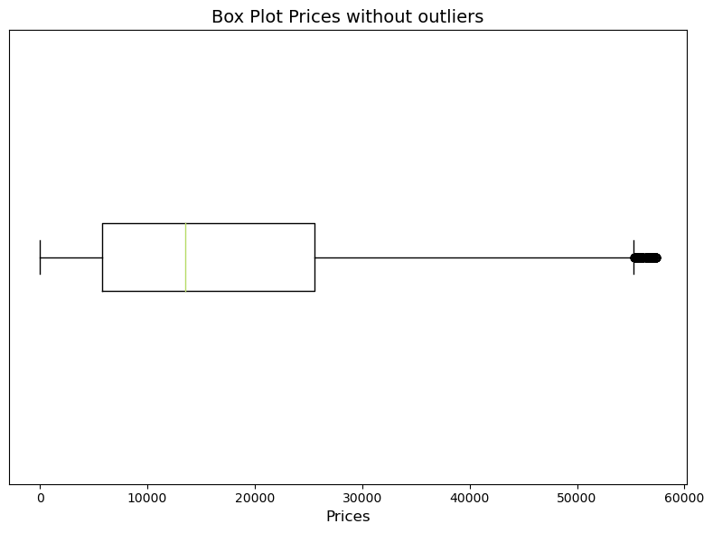

```python
plt.figure(figsize=(8, 6))  # Ajusta el tamaño de la figura
plt.boxplot(df_sin_outliers['price'], vert=False)  # Crea un box plot horizontal
plt.xlabel('Prices', fontsize=12)
plt.title('Box Plot Prices without outliers', fontsize=14)
plt.yticks([])  # Elimina las etiquetas del eje y
plt.show()
```

We are going to do the same but with the 'year' column.

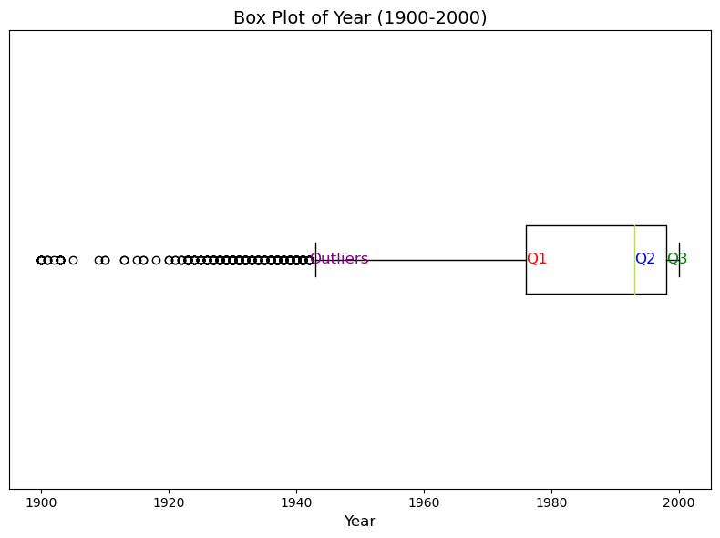

```python
# Filtrar los años entre 1900 y 2000
filtered_df = df[(df['year'] >= 1900) & (df['year'] <= 2000)]

# Crear el box plot
plt.figure(figsize=(8, 6))  # Ajusta el tamaño de la figura
plt.boxplot(filtered_df['year'], vert=False)  # Crea un box plot horizontal

# Etiquetas para los cuartiles
q1 = filtered_df['year'].quantile(0.25)
q2 = filtered_df['year'].quantile(0.5)
q3 = filtered_df['year'].quantile(0.75)

plt.text(q1, 1, 'Q1', verticalalignment='center', fontsize=12, color='red')
plt.text(q2, 1, 'Q2', verticalalignment='center', fontsize=12, color='blue')
plt.text(q3, 1, 'Q3', verticalalignment='center', fontsize=12, color='green')

# Etiqueta para los valores atípicos
outliers = filtered_df[(filtered_df['year'] < q1 - 1.5 * (q3 - q1)) | (filtered_df['year'] > q3 + 1.5 * (q3 - q1))]['year']
plt.text(max(outliers), 1, 'Outliers', verticalalignment='center', fontsize=12, color='purple')

plt.xlabel('Year', fontsize=12)
plt.title('Box Plot of Year (1900-2000)', fontsize=14)
plt.yticks([])  # Elimina las etiquetas del eje y

plt.show()
```

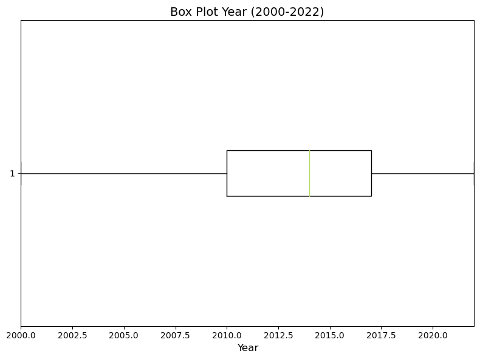

```python
# Establecer un rango de años deseado
year_range = (2000, 2022)

# Filtrar los datos en el rango de años
filtered_year_data = df_cleaned[(df_cleaned['year'] >= year_range[0]) & (df_cleaned['year'] <= year_range[1])]

# Boxplot de la columna 'year' con el rango especificado
plt.figure(figsize=(8, 6))
plt.boxplot(filtered_year_data['year'], vert=False)
plt.xlabel('Year', fontsize=12)
plt.title('Box Plot Year (2000-2022)', fontsize=14)

# Establecer el límite en el eje x para mostrar solo el rango deseado
plt.xlim(year_range)

plt.show()
```

```python
# Calculate the total number of unique VINs (total vehicles)
total_vehicles = df['VIN'].nunique()

# Print the total number of vehicles
print(f'Total number of vehicles: {total_vehicles}')
```

```
Total number of vehicles: 118264
```

```python
# Calculate the total number of vehicles from 1900 to 2000
total_vehicles_1900_to_2000 = df[(df['year'] >= 1900) & (df['year'] <= 2000)]['VIN'].nunique()

# Calculate the total number of vehicles from 2000 to 2022
total_vehicles_2000_to_2022 = df[(df['year'] >= 2000) & (df['year'] <= 2022)]['VIN'].nunique()

# Print the results
print(f'Total vehicles from 1900 to 2000: {total_vehicles_1900_to_2000}')
print(f'Total vehicles from 2000 to 2022: {total_vehicles_2000_to_2022}')
```

```
Total vehicles from 1900 to 2000: 3785
Total vehicles from 2000 to 2022: 114557
```

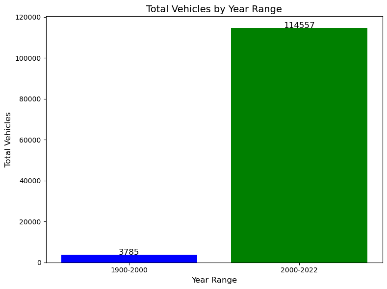

```python
# Calculate the total number of vehicles from 1900 to 2000
total_vehicles_1900_to_2000 = df[(df['year'] >= 1900) & (df['year'] <= 2000)]['VIN'].nunique()

# Calculate the total number of vehicles from 2000 to 2022
total_vehicles_2000_to_2022 = df[(df['year'] >= 2000) & (df['year'] <= 2022)]['VIN'].nunique()

# Create a bar chart
years = ['1900-2000', '2000-2022']
total_vehicles = [total_vehicles_1900_to_2000, total_vehicles_2000_to_2022]

plt.figure(figsize=(8, 6))
plt.bar(years, total_vehicles, color=['blue', 'green'])
plt.xlabel('Year Range', fontsize=12)
plt.ylabel('Total Vehicles', fontsize=12)
plt.title('Total Vehicles by Year Range', fontsize=14)

# Add values on top of the bars
for i, v in enumerate(total_vehicles):
    plt.text(i, v + 10, str(v), ha='center', fontsize=12)

plt.show()
```

The bar chart provides a visual representation of the total number of vehicles put up for sale within two distinct year ranges. The first bar, labeled "1900-2000," shows that there are 3,785 vehicles available for sale, ranging from the early 1900s to the year 2000. In contrast, the second bar, labeled "2000-2022," represents a significantly larger count of 114,557 vehicles that have been made available for sale between 2000 and the present day (2022). This chart allows for a clear comparison between the number of older vehicles from the previous century and the more recent vehicles offered for sale in the 21st century.

We find it interesting to analyze how many vehicles are below the lower limit of 2000, as these are classic vehicles. These vehicles are often considered collectibles due to their age and historical value.

Let's go back to the original boxplot, excluding outliers from the year 2000 and onwards to make our analysis more concise.

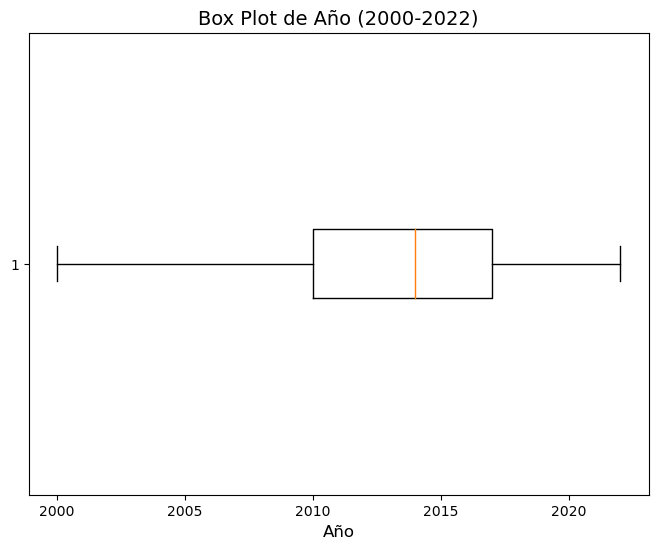

```python
# Establecer un rango de años deseado (desde 2000 en adelante)
year_range = (2000, 2022)  # Cambia el límite inferior a 1990

# Filtrar los datos en el rango de años
filtered_year_data = df_cleaned[(df_cleaned['year'] >= year_range[0]) & (df_cleaned['year'] <= year_range[1])]

# Boxplot de la columna 'year' con el nuevo rango especificado
plt.figure(figsize=(8, 6))
plt.boxplot(filtered_year_data['year'], vert=False)
plt.xlabel('Año', fontsize=12)
plt.title('Box Plot de Año (2000-2022)', fontsize=14)  # Actualiza el título
plt.xticks(range(2000, 2023, 5))  # Establece las marcas en el eje x cada 5 años

plt.show()
```

We are going to create a boxplot of 'odometer'.

- Minimum odometer reading: 0.0
- Maximum odometer reading: 10000000.0

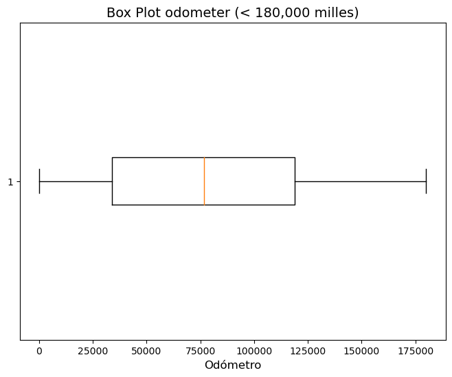

```python
# Filtrar los datos de 'odometer' dentro del rango deseado
filtered_odometer_data = df_cleaned[df_cleaned['odometer'] < 180000]

# Boxplot de la columna 'odometer' después del filtro
plt.figure(figsize=(8, 6))
plt.boxplot(filtered_odometer_data['odometer'], vert=False)
plt.xlabel('Odómetro', fontsize=12)
plt.title('Box Plot odometer (< 180,000 milles)', fontsize=14)
plt.show()
```

The reason we have used cars with a mileage of 0 to 180.000 milles in the analysis is that this range encompasses most vehicles that are in reasonably good condition and still in usable condition. Here are some reasons to consider this range:

1. **Overall Condition**: Vehicles with an odometer reading in this range are generally considered to be in good condition and suitable for daily use. This is especially relevant if we are interested in analyzing vehicles that are still in operating condition without major issues.
2. **Market Relevance**: Many buyers look for used vehicles with odometers in this range as they tend to be more affordable and have a more comprehensive and accessible maintenance history.
3. **Competitive Pricing**: Another important reason is the availability of competitive pricing data within this range, making comparisons and analysis more straightforward.
4. **Less Significant Wear**: Vehicles with odometers in this range have generally experienced less significant wear and tear compared to those with much higher odometer readings, making them more reliable in terms of mechanics and safety.
5. **Broader Market**: If we are analyzing trends in the buying and selling of used vehicles, this range is relevant because it represents the majority of the market.

However, it's important to remember that the choice of the odometer range depends on the specific goals of our analysis. In the case of analyzing historical vehicles, for example, we might choose a different range.

[figure not shown]

```python
# Create a figure with subplots for the three boxplots
fig, axs = plt.subplots(1, 3, figsize=(16, 6))

# Boxplot for 'price' without outliers
axs[0].boxplot(df_sin_outliers['price'], vert=False)
axs[0].set_xlabel('Prices', fontsize=12)
axs[0].set_title('Box Plot of Prices without Outliers', fontsize=14)
axs[0].set_yticks([])

# Set the desired year range (from 1990 onwards)
year_range = (2000, 2022)  # Update the lower limit to 1990

# Filter the data within the year range
filtered_year_data = df_cleaned[(df_cleaned['year'] >= year_range[0]) & (df_cleaned['year'] <= year_range[1])]

# Boxplot for 'year' with the new specified range
axs[1].boxplot(filtered_year_data['year'], vert=False)
axs[1].set_xlabel('Year', fontsize=12)
axs[1].set_title('Box Plot of Year (1990-2022)', fontsize=14)
axs[1].set_xticks(range(2000, 2023, 5))  # Set x-axis ticks every 5 years

# Filter the data for 'odometer' within the desired range
filtered_odometer_data = df_cleaned[df_cleaned['odometer'] < 180000]

# Boxplot for 'odometer' with the specified range
axs[2].boxplot(filtered_odometer_data['odometer'], vert=False)
axs[2].set_xlabel('Odometer', fontsize=12)
axs[2].set_title('Box Plot of Odometer (< 180,000)', fontsize=14)

# Adjust spacing between subplots
plt.tight_layout()

# Show the figure
plt.show()
```

Here we can visualize the three boxplots in a single image for more convenient visual analysis.

### Remove any data point with null values.

```python
# Specify the subset of columns to consider
columns_to_check = ['year', 'price', 'odometer']

# Remove rows with null values in the specified columns
df_cleaned = df_cleaned.dropna(subset=columns_to_check)
```

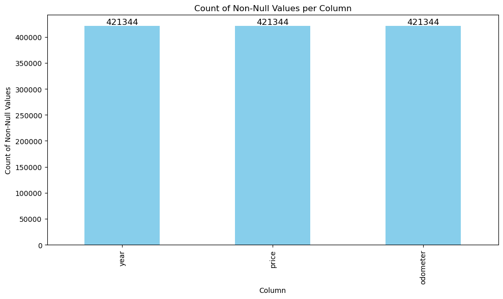

```python
# Select the columns of interest
selected_columns = ['year', 'price', 'odometer']

# Calculate the count of non-null values in the selected columns
non_null_counts = df_cleaned[selected_columns].count()

# Create the bar chart
plt.figure(figsize=(10, 6))
ax = non_null_counts.plot(kind='bar', color='skyblue')
plt.title('Count of Non-Null Values per Column')
plt.xlabel('Column')
plt.ylabel('Count of Non-Null Values')

# Display the exact number above each column
for i, v in enumerate(non_null_counts):
    ax.text(i, v, str(v), ha='center', va='bottom', fontsize=12)

# Show the chart
plt.tight_layout()
plt.show()
```

### What’s the resulting number of rows? What percentage of rows did we remove due to the cleaning and removing of outliers? Is the dataset still usable? Why?

### What’s the resulting number of rows? What percentage of rows did we remove due to the cleaning and removing of outliers? Is the dataset still usable? Why?

[figure not shown]

## **Feature Relations**

1. **Plot the correlation Matrix.**
   - Describe the process of creating a correlation matrix and its significance in understanding relationships between variables.
1. **Positive correlation between price and year.**
   - Explain why there is a positive correlation between the price of a car and the year it was manufactured.
   - Provide insights into how newer cars tend to have higher prices and how this relationship can be graphically represented.
1. **Negative correlation between price and odometer.**
   - Discuss the negative correlation observed between a car's price and its odometer reading.
   - Explain why, in general, cars with lower mileage tend to have higher prices.
   - Include a code snippet to create a scatter plot that visually represents this negative correlation.
1. **Utilize Seaborn's `pairplot()` for comprehensive analysis.**
   - Describe the use of Seaborn's `pairplot()` to analyze multiple scatterplots simultaneously.
   - Discuss how this visualization technique can help identify relationships between variables beyond price, year, and odometer.

```python
# Crear un nuevo DataFrame con las columnas seleccionadas
selected_columns = ['price', 'year', 'odometer']
new_df = df_cleaned[selected_columns]

# Guardar el nuevo DataFrame en un archivo CSV
new_df.to_csv('nuevo_dataframe.csv', index=False)
```

```python
new_df.describe()
```

|  | price | year | odometer |
| --- | --- | --- | --- |
| count | 4.213440e+05 | 421344.000000 | 4.213440e+05 |
| mean | 7.598356e+04 | 2011.225244 | 9.822513e+04 |
| std | 1.226205e+07 | 9.463345 | 2.141207e+05 |
| min | 0.000000e+00 | 1900.000000 | 0.000000e+00 |
| 25% | 5.975000e+03 | 2008.000000 | 3.795100e+04 |
| 50% | 1.398800e+04 | 2013.000000 | 8.582750e+04 |
| 75% | 2.649500e+04 | 2017.000000 | 1.338000e+05 |
| max | 3.736929e+09 | 2022.000000 | 1.000000e+07 |

```python
correlation_matrix = new_df.corr()
correlation_matrix
```

|  | price | year | odometer |
| --- | --- | --- | --- |
| price | 1.000000 | -0.004940 | 0.010032 |
| year | -0.004940 | 1.000000 | -0.157215 |
| odometer | 0.010032 | -0.157215 | 1.000000 |

According to this correlation matrix, there doesn't seem to be a strong relationship between these three variables in our dataset. Therefore, I'm going to select only the years that we're interested in analyzing (from 2000 to 2022), as well as prices (from 0 to $100,000) and odometer readings (from 0 to 180,000 miles). This will allow us to focus on a more relevant subset of data and possibly find clearer relationships among the selected variables.

```python
# Filtrar new_df
filtered_df = new_df[(new_df['year'] >= 2000) & (new_df['year'] <= 2022) & (new_df['price'] >= 0) & (new_df['price'] <= 100000) & (new_df['odometer'] >= 0) & (new_df['odometer'] <= 180000)]


correlation_matrix = filtered_df.corr()
correlation_matrix
```

|  | price | year | odometer |
| --- | --- | --- | --- |
| price | 1.000000 | 0.472770 | -0.441789 |
| year | 0.472770 | 1.000000 | -0.641635 |
| odometer | -0.441789 | -0.641635 | 1.000000 |

Ahora, en nuestra matriz de correlación podemos observar:

The correlation between 'price' and 'year' is positive (0.472770), indicating a moderate positive relationship between the price and the year of the vehicle. This means that, in general, newer vehicles tend to have higher prices.

The correlation between 'price' and 'odometer' is negative (-0.441789), suggesting a moderate negative relationship between the price and the mileage. In other words, vehicles with lower mileage tend to have higher prices, but the correlation is relatively weak.

The correlation between 'year' and 'odometer' is negative (-0.641635), implying that, in general, newer vehicles tend to have lower mileage. This correlation is moderately high.

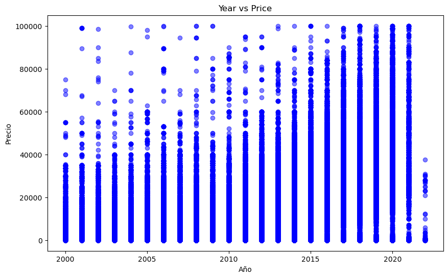

```python
import matplotlib.pyplot as plt

# Datos
x = filtered_df['year']  # Año en el eje x
y = filtered_df['price']  # Precio en el eje y

# Crear el scatter plot
plt.figure(figsize=(10, 6))
plt.scatter(x, y, alpha=0.5, color='blue')
plt.title('Year vs Price')
plt.xlabel('Año')
plt.ylabel('Precio')

# Mostrar el gráfico
plt.show()
```

Podemos observar que dispersión que muestra el scatterplot es de cómo los precios de los vehículos están distribuidos en función del año. Al haber una correlación positiva, observamos que los puntos tienden a agruparse en una dirección ascendente, lo que confirma la tendencia de que los vehículos más nuevos tienden a tener precios más altos.

Correlación entre el precio y el odometro: La correlación negativa observada entre el precio de un automóvil y la lectura del odómetro se refiere a la tendencia general de que los automóviles con un menor kilometraje tienden a tener precios más altos. Esta correlación sugiere que, en promedio, los vehículos con menos desgaste y menos millas recorridas tienden a ser más costosos en el mercado de vehículos usados.

La razón detrás de esta correlación negativa es bastante intuitiva:

1. **Menos desgaste**: Los automóviles con menos millas en el odómetro han experimentado menos desgaste y desgaste mecánico en comparación con aquellos con un odómetro más alto. Esto significa que es menos probable que tengan problemas mecánicos significativos, lo que los hace más atractivos y valiosos para los compradores.
2. **Mayor vida útil restante**: Un automóvil con menos millas recorridas generalmente tiene más vida útil restante en términos de durabilidad y confiabilidad. Los compradores están dispuestos a pagar más por un vehículo que les ofrezca más años de servicio sin costosos reparaciones.
3. **Menos riesgo de ocultar desgaste**: Un vehículo con un odómetro más bajo también tiene menos probabilidades de que se haya manipulado o que se hayan ocultado problemas importantes, ya que el desgaste y el kilometraje son factores visibles.

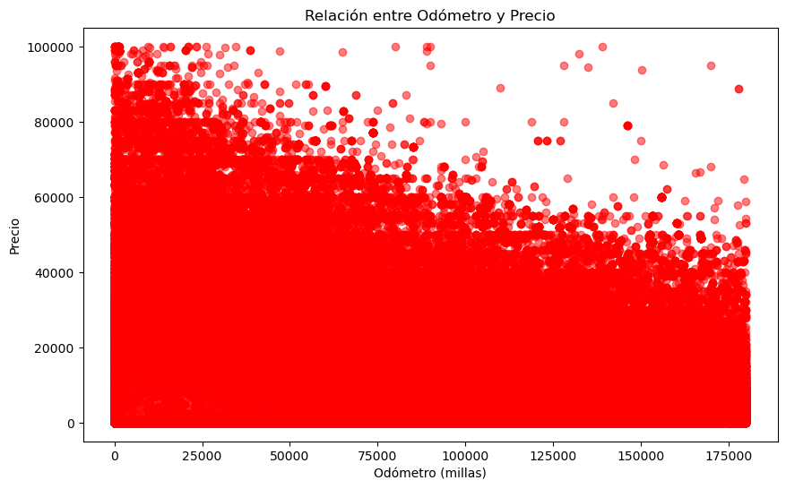

```python
import matplotlib.pyplot as plt

# Datos
x = filtered_df['odometer']  # Odómetro en el eje x
y = filtered_df['price']  # Precio en el eje y

# Crear el scatter plot
plt.figure(figsize=(10, 6))
plt.scatter(x, y, alpha=0.5, color='red')
plt.title('Relación entre Odómetro y Precio')
plt.xlabel('Odómetro (millas)')
plt.ylabel('Precio')

# Mostrar el gráfico
plt.show()
```

In this scatter plot, we can observe that the points tend to cluster in a downward direction, confirming the trend that vehicles with fewer miles on the odometer tend to have higher prices.

1. **Utilize Seaborn's `pairplot()` for comprehensive analysis.**
   - Describe the use of Seaborn's `pairplot()` to analyze multiple scatterplots simultaneously.
   - Discuss how this visualization technique can help identify relationships between variables beyond price, year, and odometer.

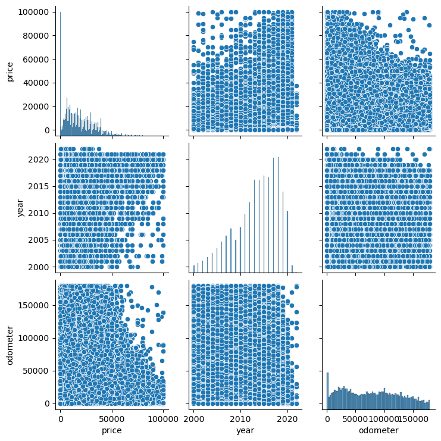

```python
import seaborn as sns

sns.pairplot(data=filtered_df)
```

El `pairplot` es una herramienta muy útil para visualizar la relación entre múltiples variables de un conjunto de datos. En este caso, al haber limitado los valores de las variables (año, precio y odómetro) a un rango específico, podemos esperar que el `pairplot` nos proporcione una vista más clara de cómo estas variables se relacionan entre sí en ese rango particular.

Dado el rango de valores que estamos considerando:

- Año: Desde 2000 hasta 2022
- Precio: Desde 0 hasta 100,000 dólares
- Odómetro: Desde 0 hasta 180,000 millas

El `pairplot` nos mostrará gráficos de dispersión entre todas las combinaciones posibles de estas tres variables. Aquí hay algunas conclusiones que podríamos obtener del `pairplot`:

1. **Relación positiva entre precio y año**: Esperamos ver una tendencia general en la que los puntos se agrupen hacia arriba y hacia la derecha, lo que indicaría que, en este rango de años y precios, los vehículos más nuevos (años más altos) tienden a tener precios más altos.
2. **Relación negativa entre precio y odómetro**: Similar a la correlación negativa que observamos en la matriz de correlación, esperamos ver una tendencia donde los puntos se agrupen hacia abajo y hacia la derecha, lo que sugiere que los vehículos con menos millas recorridas (odómetros más bajos) tienden a tener precios más altos.
3. **Distribución de datos**: También podemos esperar ver cómo se distribuyen los datos en estos rangos. Por ejemplo, si hay muchos vehículos en un rango específico de precios y años, eso se reflejará en la densidad de puntos en el `pairplot`.
4. **Valores atípicos**: Podríamos identificar valores atípicos (outliers) que se desvían significativamente de las tendencias generales, lo que podría indicar casos inusuales en el conjunto de datos.

En resumen, el `pairplot` nos proporcionará una visión visual de cómo estas tres variables se relacionan entre sí dentro de los rangos específicos que hemos definido. Nos ayudará a confirmar las tendencias que observamos en la matriz de correlación y a identificar cualquier patrón interesante en el conjunto de datos.

[figure not shown]

## **Feature Analysis**

We want to see the distribution of the values of a feature.

### Plot a Histogram of the Feature 'Odometer'

To visualize the distribution of the 'odometer' feature, we'll create a histogram with 50 bins. This will help us identify any frequency maximums within specific odometer value ranges and understand the patterns in the data.

Plot a histogram of the feature year.’ Use 20 bins for the plot. You’ll see a frequency maximum for a specific year value range. Explain it.

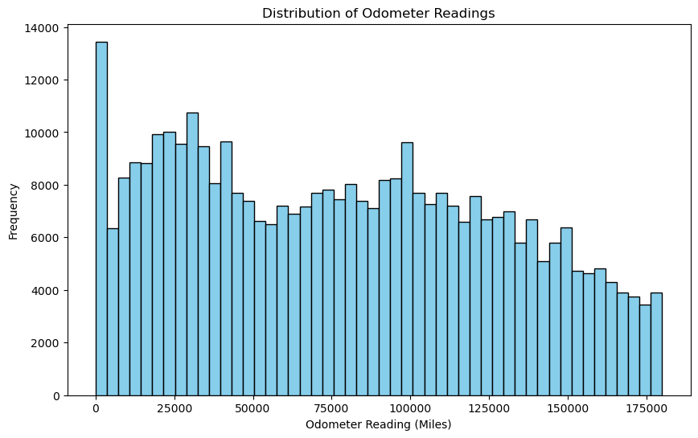

```python
# Create a histogram for the 'odometer' feature with 50 bins
plt.figure(figsize=(10, 6))
plt.hist(filtered_df['odometer'], bins=50, color='skyblue', edgecolor='black')
plt.xlabel('Odometer Reading (Miles)')
plt.ylabel('Frequency')
plt.title('Distribution of Odometer Readings')
plt.show()
```

This histogram provides insights into the distribution of vehicle mileage, highlighting common mileage levels and their availability in the dataset.

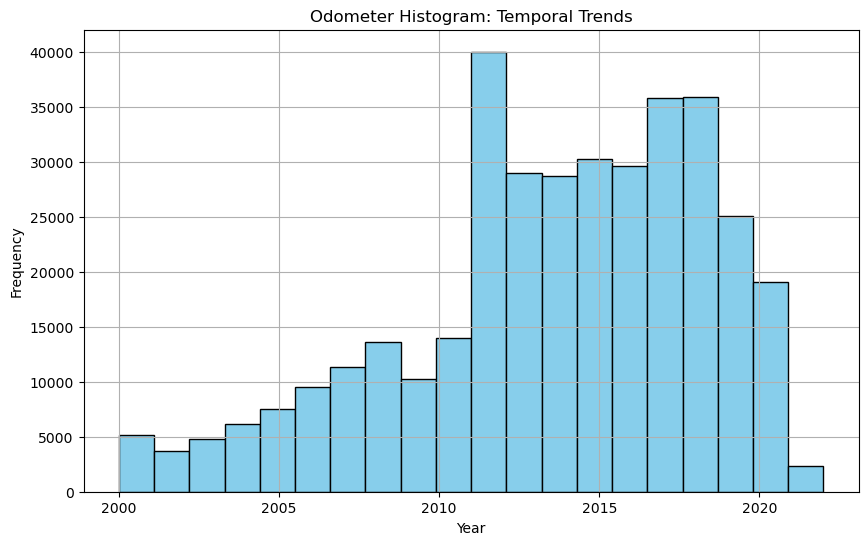

```python
# Plot a histogram of the 'year' feature with 20 bins
plt.figure(figsize=(10, 6))
plt.hist(filtered_df['year'], bins=20, color='skyblue', edgecolor='black')
plt.xlabel('Year')
plt.ylabel('Frequency')
plt.title('Odometer Histogram: Temporal Trends')
plt.grid(True)

# Show the histogram
plt.show()
```

[figure not shown]

**Conclusion**

*You worked as a Machine Learning analyst to make all the previous analyses, but you're now the boss of BestCars Inc. Your company owns all those cars, and you lease them to other companies (This is the main business of ALD Automotive, for example). You know that their storage and maintenance aren’t cheap. You have to make a decision.*

1. **Sell all the cars older than a specific year.**
2. **Sell all the cars with heavy usage (significant odometer values).**
3. **Sell all the cars with a bad status. Remember the ‘condition’ feature.**

What would you do? There’s no right or wrong answer to this question. The point is that you need to build a narrative for your decisions. As an ML engineer or as the boss, it doesn’t matter, you’ll have to convince others of your actions. As an ML Engineer, you have to convince your boss, and the boss needs to convince the shareholders.

Being an ML Engineer or a Data Scientist is more than just knowing some technical things. Your value will multiply if you explain what you see in the data.

Think about it: Do I have enough data to make a decision? What extra data do I need? Why?

First of all, we need to create an overview of car prices by year in order to filter out the lower-value cars and keep only the higher-value ones.

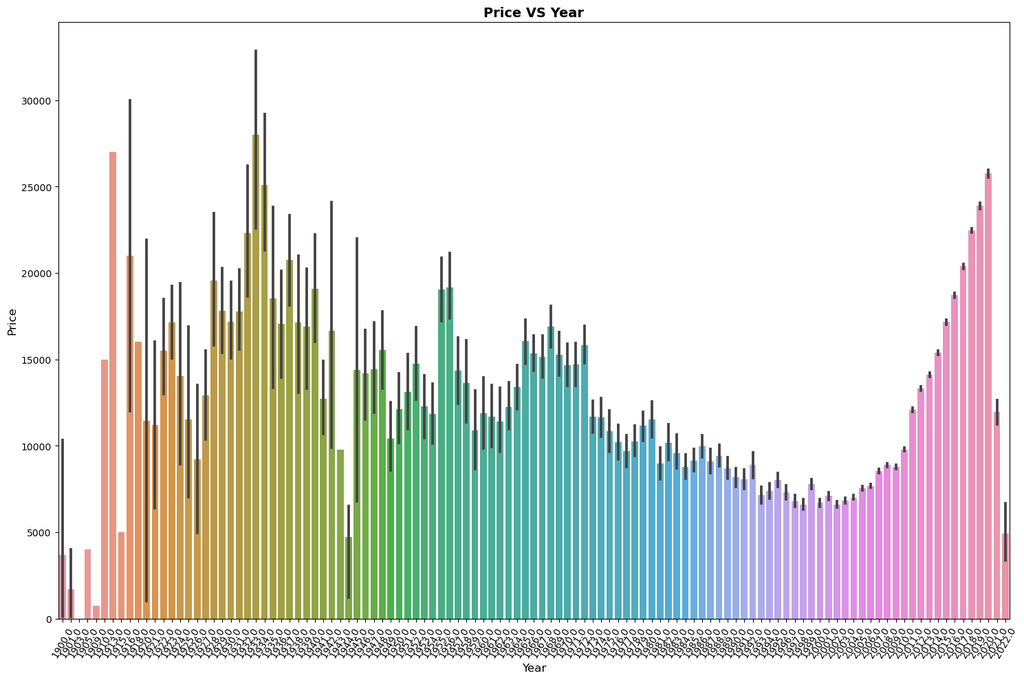

```python
# Primero vamos a filtrar el DataFrame para incluir solo precios hasta $40,000
filtered_df = clean_df[clean_df['price'] <= 40000]

plt.rcParams["figure.autolayout"] = True
sns.set_palette('summer_r')
plt.figure(figsize=(15, 10))
sns.barplot(y=filtered_df['price'], x=filtered_df['year'])
plt.title("Price VS Year", fontsize=14, fontweight='bold')
plt.xlabel('Year', fontsize=12)
plt.xticks(rotation=60)
plt.ylabel('Price', fontsize=12)
plt.tight_layout()
plt.show()
```

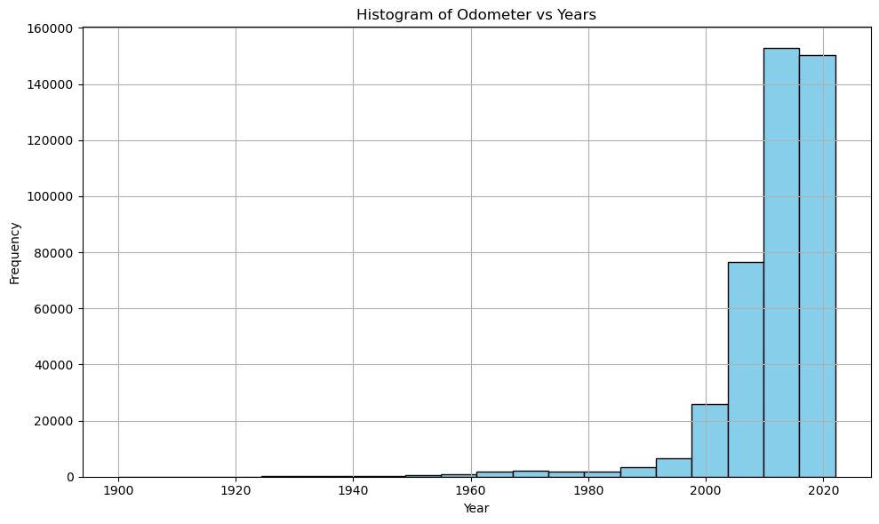

```python
# Plot a histogram of the 'year' feature with 20 bins
plt.figure(figsize=(10, 6))
plt.hist(clean_df['year'], bins=20, color='skyblue', edgecolor='black')
plt.xlabel('Year')
plt.ylabel('Frequency')
plt.title('Histogram of Odometer vs Years')
plt.grid(True)

# Show the histogram
plt.show()
```

### LEASING

**If our client is considering entering the vehicle leasing business and is contemplating what to do with classic vehicles in their fleet, they might consider some recommendations such as:**

1. **Specialized Maintenance**: Classic vehicles require specialized maintenance and care due to their age and historical value. Consider investing in workshops or mechanics with experience in repairing and restoring classic cars to keep them in optimal condition.
2. **Specific Market Segment**: Classic vehicles have a specific target market, composed of collectors and car enthusiasts. Consider directing these vehicles to a market segment that appreciates them and is willing to pay more for their temporary use.
3. **Competitive Pricing**: Despite their historical value, set competitive prices for leasing classic vehicles. This can attract more customers interested in experiencing the driving of these cars without compromising their budget.
4. **Specific Insurance**: Ensure you have appropriate insurance for classic vehicles. These cars can be difficult to replace, so you need coverage that reflects their historical and market value.
5. **Records and Documentation**: *Maintain meticulous documentation of the history and maintenance of your classic vehicles.* This can increase their appeal to customers and help justify higher prices.
6. **Special Events**: Consider offering classic vehicles for special events such as weddings, photoshoots, or exhibitions. This can generate additional income and promotion for your business.
7. **Strategic Rotation**: Since classic vehicles may be more susceptible to wear and tear, consider a strategic rotation in your fleet. Keep a variety of classic vehicles and update or restore them as needed.
8. **Customer Education**: *Provide information and education to your customers about the value and history of the classic vehicles you offer.* This can increase their appreciation for these cars and their willingness to rent them.
9. **Continuous Evaluation**: Continuously track the demand and performance of your classic vehicles in the leasing market. Adjust your strategy as necessary to maximize benefits.

*Ultimately, the decision to include classic vehicles in the leasing fleet will depend on the target audience, available resources, and commitment to maintaining and promoting these unique cars.*

### **My recomendation:**

**Selling all cars manufactured before the year 2010, including classic vehicles, could be the following:**

- **Maintenance and Repair Costs**: Cars manufactured before the year 2010, including classic vehicles, tend to require more frequent and costly maintenance and repairs due to their age and the lack of easily available spare parts. This can result in a significant increase in operational costs for your leasing company. By selling these vehicles, you can avoid the ongoing expenses associated with their maintenance and allocate those resources to newer and more profitable vehicles.

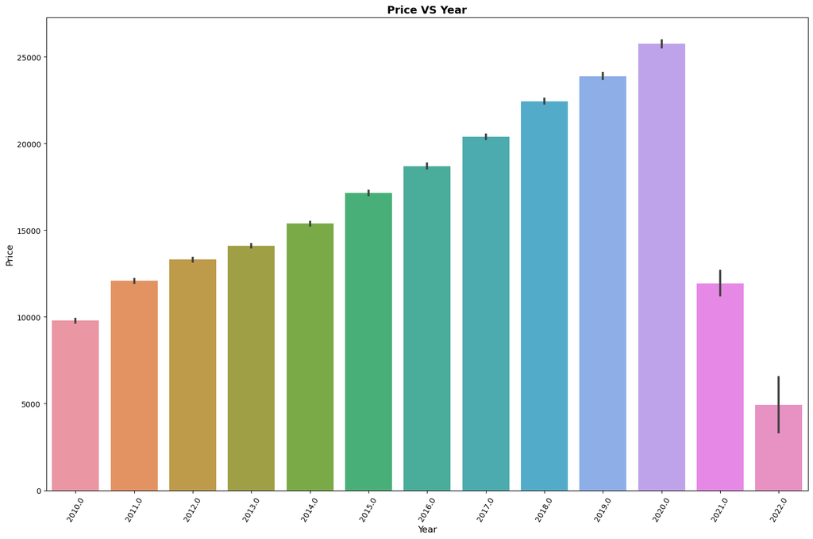

```python
# Crear un nuevo DataFrame con años a partir de 2010
new2_df = clean_df[clean_df['year'] >= 2010]

# Filtrar el DataFrame para incluir solo precios hasta $40,000
filtered_df = new2_df[new2_df['price'] <= 40000]

import matplotlib.pyplot as plt
import seaborn as sns

plt.rcParams["figure.autolayout"] = True
sns.set_palette('summer_r')
plt.figure(figsize=(15, 10))
sns.barplot(y=filtered_df['price'], x=filtered_df['year'])
plt.title("Price VS Year", fontsize=14, fontweight='bold')
plt.xlabel('Year', fontsize=12)
plt.xticks(rotation=60)
plt.ylabel('Price', fontsize=12)
plt.tight_layout()
plt.show()
```

```python
# Filtrar el DataFrame para incluir solo datos a partir del año 2010
new2_df = clean_df[clean_df['year'] >= 2010]

# Contar la cantidad de coches en venta por año
car_counts_by_year = new2_df['year'].value_counts().sort_index()

# Imprimir el resultado
print(car_counts_by_year)
```

```
2010.0    15829
2011.0    20341
2012.0    23898
2013.0    30794
2014.0    30283
2015.0    31538
2016.0    30434
2017.0    36420
2018.0    36369
2019.0    25375
2020.0    19298
2021.0     2396
2022.0      133
Name: year, dtype: int64
```

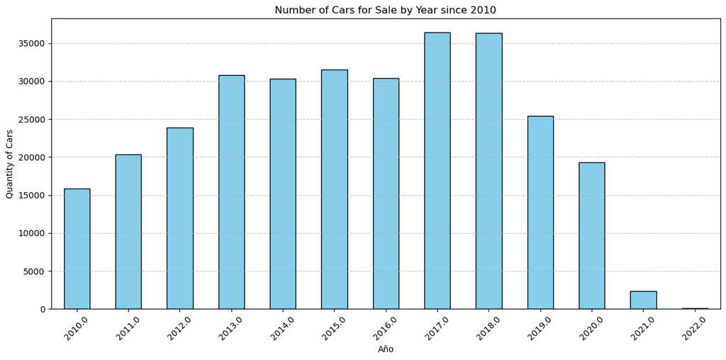

```python
# Filtrar el DataFrame para incluir solo datos a partir del año 2010
new_df = clean_df[clean_df['year'] >= 2010]

# Contar la cantidad de coches en venta por año
car_counts_by_year = new_df['year'].value_counts().sort_index()

# Crear un gráfico de barras
plt.figure(figsize=(12, 6))
car_counts_by_year.plot(kind='bar', color='skyblue', edgecolor='black')
plt.xlabel('Año')
plt.ylabel('Quantity of Cars')
plt.title('Number of Cars for Sale by Year since 2010')
plt.xticks(rotation=45)
plt.grid(axis='y', linestyle='--', alpha=0.7)

# Mostrar el gráfico
plt.tight_layout()
plt.show()
```

**To make a decision regarding the leasing strategy in 2024, we could consider the following:**

1. **Sell all the cars older than a specific year:** We could sell all the cars manufactured before 2010. This would allow us to maintain a more up-to-date inventory, possibly more appealing to customers interested in newer cars with advanced technology.
2. **Sell all the cars with heavy usage (significant odometer values):** Evaluate the odometer distribution for the cars in your inventory. If you observe cars with significantly high odometer readings (e.g., close to or above 180,000 miles), you may consider selling those with high wear and tear, as they may require more maintenance and have a less attractive leasing value.
3. **Sell all the cars with a bad status (Remember the ‘condition’ feature):** If you have recorded information about the condition of the cars in your dataset and notice that some have a poor condition, it is advisable to sell those with significant or expensive repair issues. Keeping cars in poor condition in your inventory could result in high maintenance costs and dissatisfied customers.

The final decision will depend on a more detailed assessment of our inventory and our business objectives. It's also important to consider market conditions in 2024 and the demands of potential customers. We can conduct additional analyses, such as estimating maintenance costs for specific cars or assessing market demand, before making a definitive decision.

**The decision to sell all the cars in the inventory and embrace new technology, such as electric, hybrid, or even autonomous cars, is a bold strategy aligned with emerging trends in the automotive industry. Here are some reasons to consider this decision:**

1. **Innovation and Sustainability:** Electric and hybrid cars represent significant technological innovation in the automotive industry. These vehicles are more fuel-efficient and have a reduced environmental impact compared to traditional internal combustion engine vehicles. Embracing sustainability is a significant trend today.
2. **Trend Toward Autonomous Mobility:** Autonomous cars represent the future of mobility. Investing in this technology can position you as a leader in adopting advanced mobility solutions. Autonomous cars promise to increase road safety and radically change how people commute.
3. **Market Potential:** As more consumers become aware of the importance of sustainability and safety, the demand for electric, hybrid, and autonomous cars is likely to increase. Being at the forefront of this trend could provide a competitive advantage in the market.
4. **Inventory Upgrade:** Older cars in your inventory may require more maintenance and have a decreasing leasing value. Selling them would free up financial resources that could be invested in acquiring state-of-the-art vehicles.

However, it's also essential to consider the challenges associated with this decision, such as the initial investment required to acquire high-tech vehicles, staff training in maintenance and operation of these vehicles, and identifying a suitable market for them. Conducting a market analysis and developing a robust business plan is essential before implementing this strategy.

In summary, transitioning to new automotive technology can be an exciting and promising strategy, but it requires careful planning and a solid understanding of market trends and customer needs.

**Furthermore, in line with our recommendation, we suggest that you retain the cars from the years 2021 and 2022. These vehicles do not represent a very high value for their sale, meaning that the profits gained from selling them would not be significant compared to the investment required to replace them with more technologically advanced vehicles.**

**Keeping some diesel or gasoline cars, which are more traditional, can be a strategic decision. This allows you to maintain variety in your fleet, which can be appreciated by drivers with more traditional preferences or in areas where the infrastructure for electric vehicles is not yet fully developed.**

**Ultimately, this balanced strategy allows you to leverage the opportunities provided by modern technology while keeping options available to meet the varied needs of your customer base.**

[figure not shown]

### Columns Descriptions:

- **'id'**: Unique identification of the ad.
- **'url'**: Associated URL of the ad.
- **'region'**: The geographic region where the vehicle is located.
- **'region_url'**: Specific URL of the region.
- **'price'**: The price of the vehicle.
- **'year'**: The manufacturing year of the vehicle.
- **'manufacturer'**: The manufacturer or brand of the vehicle.
- **'model'**: The model of the vehicle.
- **'condition'**: The overall condition of the vehicle (e.g., new, used, etc.).
- **'cylinders'**: The number of cylinders in the vehicle's engine.
- **'fuel'**: The type of fuel used by the vehicle.
- **'odometer'**: The number of miles or kilometers driven by the vehicle.
- **'title_status'**: The legal status of the vehicle's title (clean, liens, etc.).
- **'transmission'**: The type of transmission in the vehicle (automatic, manual, etc.).
- **'VIN'**: The Vehicle Identification Number (VIN) of the vehicle.
- **'drive'**: The type of drive in the vehicle (front-wheel drive, rear-wheel drive, etc.).
- **'size'**: The size or category of the vehicle.
- **'type'**: The body type of the vehicle (sedan, SUV, truck, etc.).
- **'paint_color'**: The color of the vehicle's paint.
- **'image_url'**: URL of images of the vehicle.
- **'description'**: Detailed description of the vehicle.
- **'county'**: The county where the vehicle is located.
- **'state'**: The state where the vehicle is located.
- **'lat'**: The geographic latitude of the vehicle's location.
- **'long'**: The geographic longitude of the vehicle's location.
- **'posting_date'**: The date when the ad for the vehicle was posted.

### Sumary:

Investing in new technologies in the vehicle sector is crucial to stand out in today's highly competitive market. The adoption of electric, hybrid, and autonomous vehicles not only reflects a commitment to innovation and sustainability but also meets the growing demand from tech-savvy and environmentally-conscious consumers. This strategy not only sets a company apart from the competition but also positions it favorably to seize emerging opportunities in the automotive industry and remain relevant in the future.